# Pulitzer Prize Recency Bias

Zev Youra

This is a notebook looking into data about Pulitzer Prize winners.

The source of this data is the Pulitzer website; I used Puppeteer to gather the data (because it was not easily scrapeable with R), and then cleaned it up a little in R before bringing it into this notebook. The data here contains information about all Pulitzer winners in Journalism categories, from 2000-2018 (year of prize).

This is a rough, exploratory notebook, meant to help me learn about the issue and experiment with presentation; the graphics are not at a publishable level of polish.

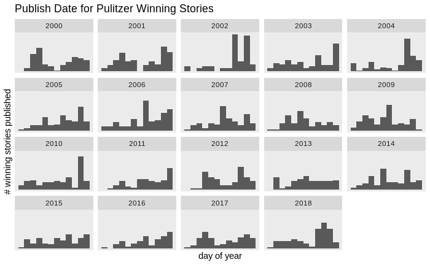

```r
data %>%
  ggplot(aes(yday(published))) +
    geom_histogram(bins = 12) +
    scale_x_continuous(breaks = NULL) +
    scale_y_continuous(breaks = NULL) +
    facet_wrap(vars(prize_year)) +
    labs(x = "day of year", y = "# winning stories published",
         title = "Publish Date for Pulitzer Winning Stories")
```

A few things to note about this:

- counts each story published individually (can be many stories for a single awarded prize, somewhat depending on category)
- a small portion of winners do not have a publish date in the Pulitzer data, mostly photographs. More research could pin down an exact publish date for most of the ones I spot checked ([example](https://www.pulitzer.org/winners/ryan-kelly-daily-progress))
- filters out publish dates outside of the prize year – every time I’ve spot-checked these, they appear to be the date of the award presentation

Narrowing the data shown to instead show the median of the publish dates (and therefore one data point per award) does not clarify the picture much.

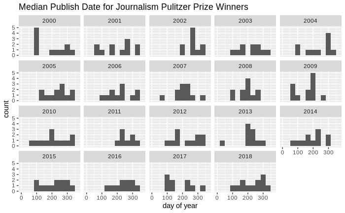

```r
data %>%
  group_by(nid) %>%
  summarise(published = median(published, na.rm = TRUE),
            category = first(category),
            prize_year = first(prize_year)) %>%
  ggplot(aes(yday(published))) +
    geom_histogram(bins = 12) +
    scale_x_continuous(limits = c(0, 366)) +
    facet_wrap(vars(prize_year)) +
    labs(title = "Median Publish Date for Journalism Pulitzer Prize Winners",
         x = "day of year")
```

Instead, let’s look by category:

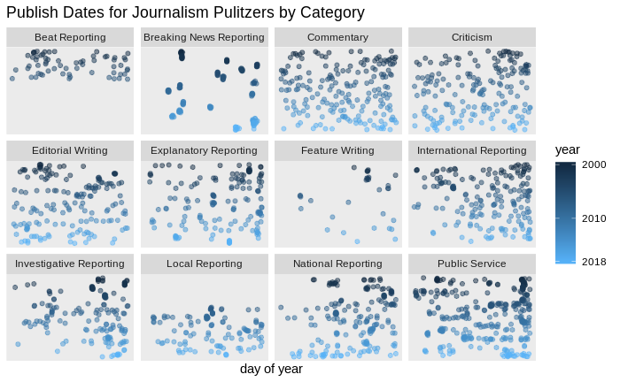

```r
data %>%
  filter(category != "Editorial Cartooning") %>%
  ggplot(aes(x = yday(published), prize_year, color = prize_year)) +
    geom_jitter(width = 0, alpha = 0.5) +
    facet_wrap(vars(category)) +
    scale_x_continuous(breaks = NULL) +
    scale_y_continuous(breaks = NULL, trans = "reverse") +
    scale_color_continuous(trans = "reverse", high = "#132B43", low = "#56B1F7",
                           breaks = c(2000, 2010, 2018)) +
    labs(title = "Publish Dates for Journalism Pulitzers by Category",
         x = "day of year", color = "year", y = NULL)
```

This shows some clearer patterns. First, “Breaking News” reporting happens in small, intense bursts, around a particular event, which can happen at any time of the year. To my eye, though, the Explanatory, International, Investigative, National, and Public Service categories all appear to have some recency bias, where winning stories tend to come out towards the end of the year. This bias also appears to be increasing, especially over the last ~5 years.

Other categories, like Beat, Commentary, Criticism, Editorial, Features, and Local, have less of an apparent pattern, with datapoints spread across the year.

Let’s see if we can illustrate this more clearly.

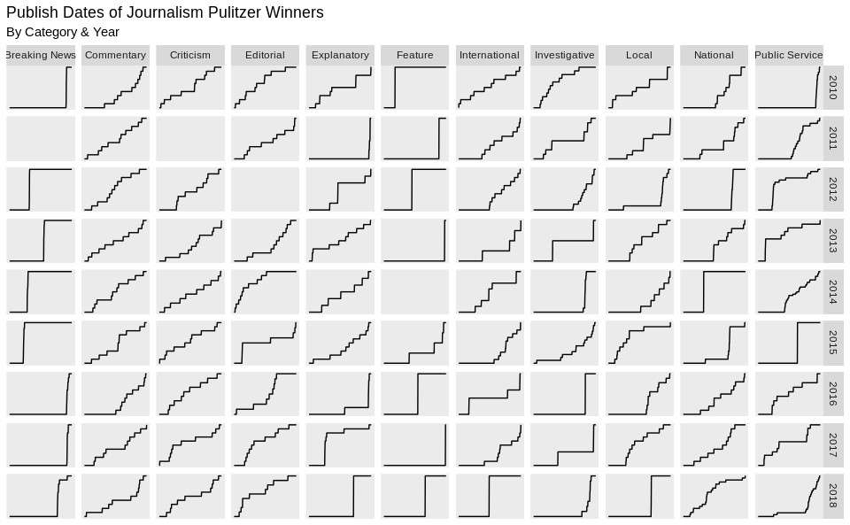

```r
cumulative_data <- data %>%
  filter(category != "Editorial Cartooning") %>%
  group_by(category, prize_year) %>%
  mutate(day = yday(published)) %>%
  count(day) %>%
  complete(day = 1:366, fill = list(n = 0)) %>%
  mutate(n = cumsum(n), max = max(n), p = n / max) %>%
  ungroup %>%
  mutate(category = str_remove(category, "Reporting|Writing") %>% str_trim)
cumulative_data %>%
  filter(prize_year >= 2010) %>%
  ggplot(aes(day, p)) +
    geom_line() +
    scale_x_continuous(breaks = NULL) +
    scale_y_continuous(breaks = NULL) +
    facet_grid(rows = vars(prize_year),
               cols = vars(category)) +
    labs(title = "Publish Dates of Journalism Pulitzer Winners",
         subtitle = "By Category & Year",
         y = NULL, x = NULL)
```

This is pretty interesting, but kind of hard to read. Worth trying overlaying them by year to attempt to simplify it and make the day of year axis read more easily.

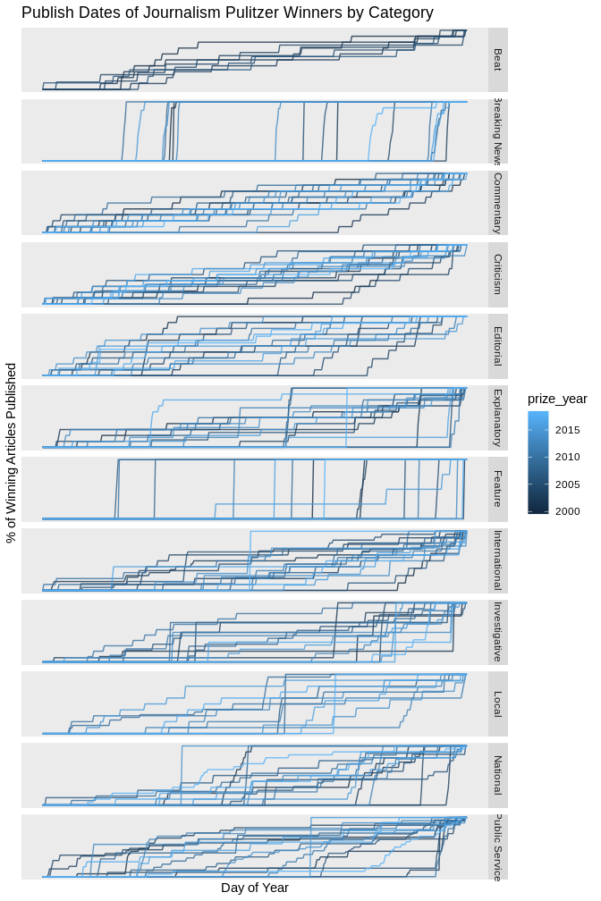

```r
cumulative_data %>%
  ggplot(aes(day, p)) +
    geom_line(aes(group = prize_year, color = prize_year), alpha = 0.8) +
    scale_x_continuous(breaks = NULL) +
    scale_y_continuous(breaks = NULL) +
    facet_grid(rows = vars(category)) +
    labs(title = "Publish Dates of Journalism Pulitzer Winners by Category",
         y = "% of Winning Articles Published", x = "Day of Year")
```

This is easier to read, but still not very clarifying.

Let’s try one last approach: when were >50% of winning stories published, per category, per year? This is similar to the median chart earlier in this notebook, but split by category.

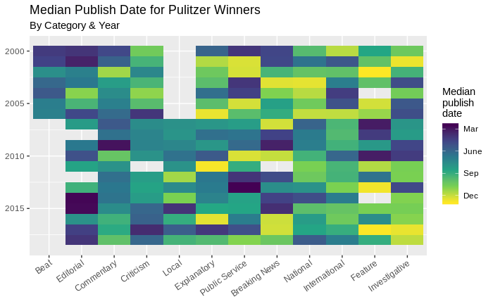

```r
cumulative_data %>%
  group_by(category, prize_year) %>%
  filter(p >= 0.5) %>%
  summarise(day = min(day)) %>%
  group_by(category) %>%
  mutate(category_median = median(day)) %>%
  ungroup() %>%
  ggplot(aes(x = fct_reorder(category, category_median), y = prize_year, fill = day)) +
    geom_tile() +
    scale_y_continuous(trans = "reverse") +
    scale_fill_viridis_c(breaks = c(60, 152, 244, 335),
                         labels = c("Mar", "June", "Sep", "Dec"),
                         begin = 1, end = 0, trans = "reverse") +
    labs(x = NULL, y = NULL, title = "Median Publish Date for Pulitzer Winners",
         subtitle = "By Category & Year", fill = "Median\npublish\ndate") +
    theme(axis.text.x = element_text(angle = 35, hjust = 1))
```

This is additional evidence towards the hypothesis raised before: some categories, especially those towards the right of the chart, do appear to have a pretty consistent pattern of publishing late in the year. In general, there’s a lot more green and yellow on this chart than purple, which speaks to an overall recency bias.

However, there’s not quite as obvious a tendency as I initially expected. There’s a lot of variance between categories, and even categories that tend towards late publishing like Investigative have years where they were published early on.

Let’s take a final look at the publish dates by category and month.

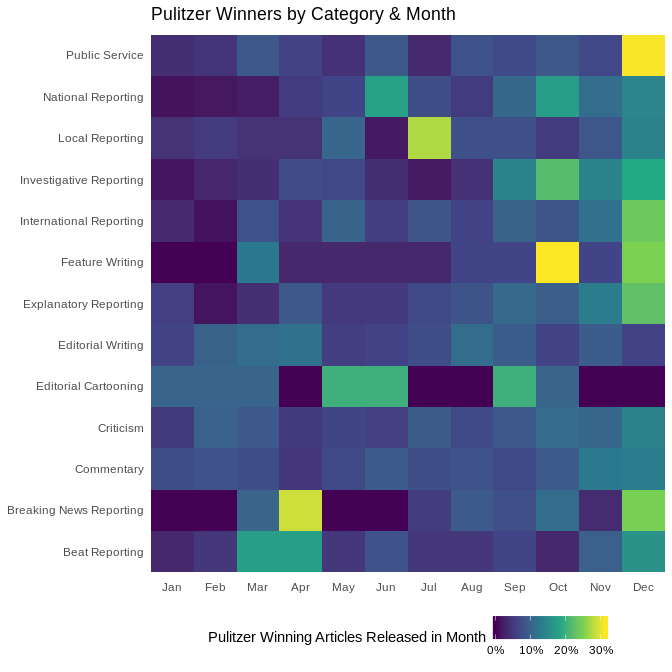

This is a pretty clear view of the bias, especially when you look at that December column. However, this view also is a bit distorted, as the number of stories that win in each category per year is different. This could be mitigated with some additional weighting, but that’s enough for now.

All in all, an interesting dataset, but this is just a quick look at it. Interesting follow-ups might include:

- per-publication tendencies
- non-journalism categories
- comparison to other prizes
- filling out missing data points manually